# HW1 - Time series graphics

#### For the last plot, modify the axis labels and title.

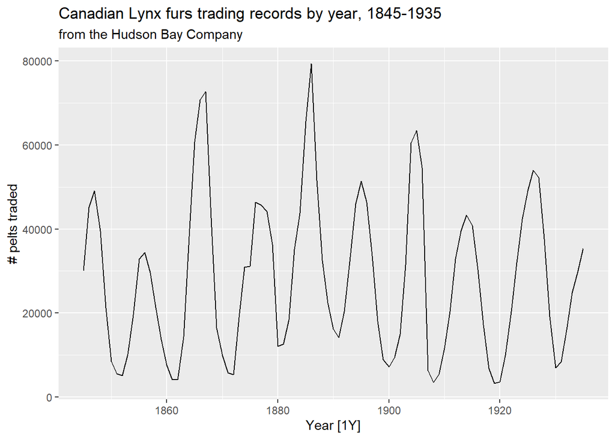

```r
autoplot(pelt, Lynx) +
  labs(title = "Canadian Lynx furs trading records by year, 1845-1935",
       subtitle = "from the Hudson Bay Company",
       y = "# pelts traded")
```

### Exercise 2.8

#### Monthly Australian retail data is provided in aus_retail. Select one of the time series as follows (but choose your own seed value):

```r
set.seed(8675309)
myseries <- aus_retail %>%
  filter(`Series ID` == sample(aus_retail$`Series ID`,1))
```

#### Explore your chosen retail time series using the following functions:autoplot(), gg_season(), gg_subseries(), gg_lag(), ACF()

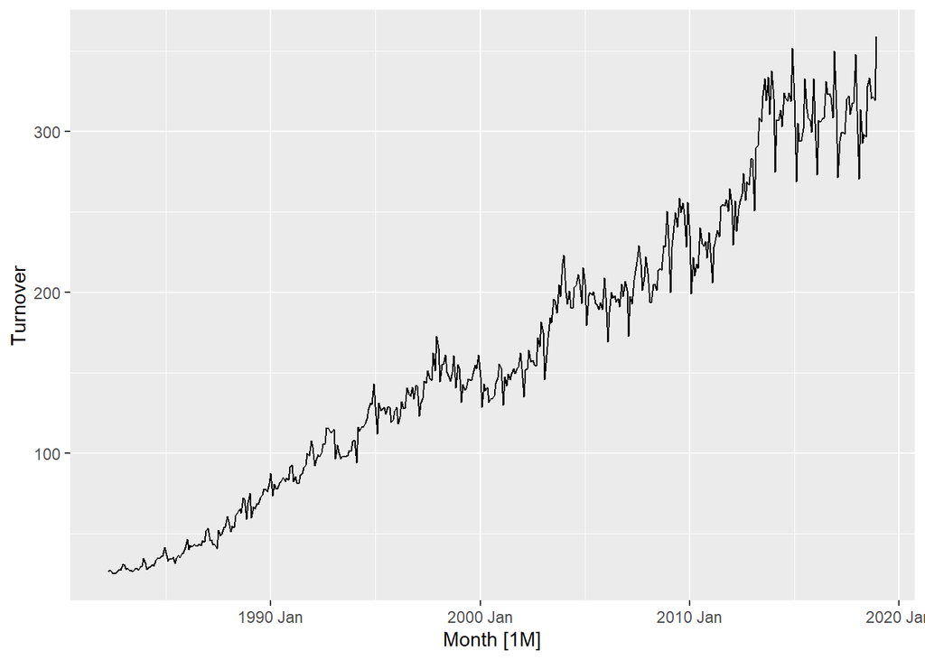

```r
autoplot(myseries)
```

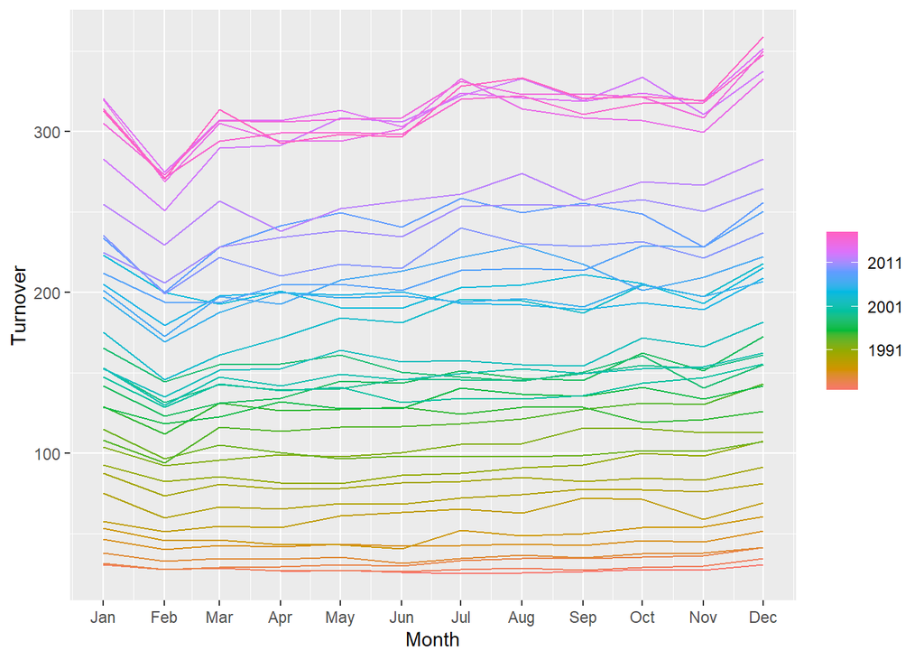

```r
gg_season(myseries)
```

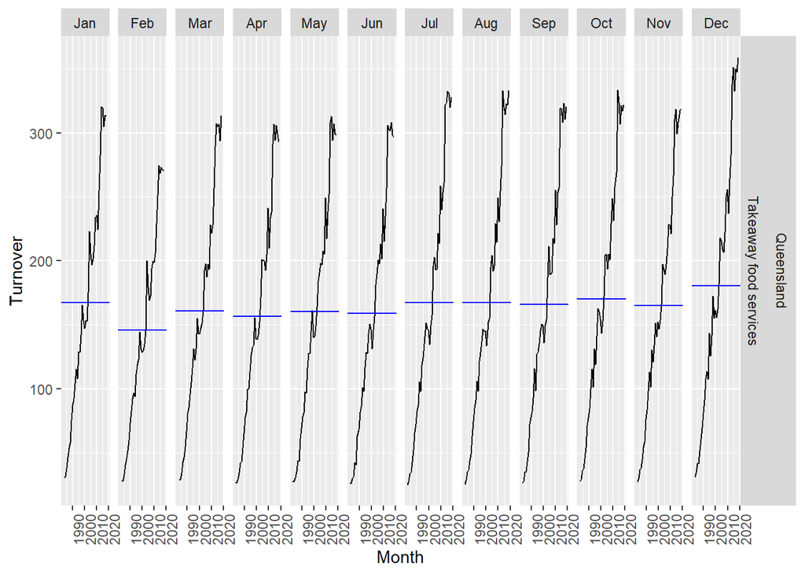

```r
gg_subseries(myseries)
```

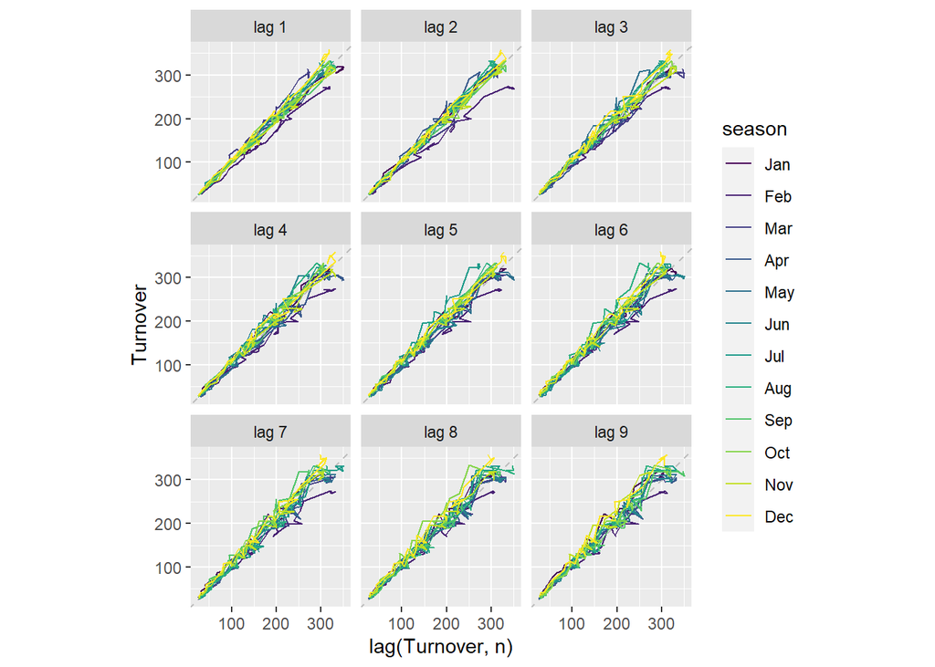

```r
gg_lag(myseries)
```

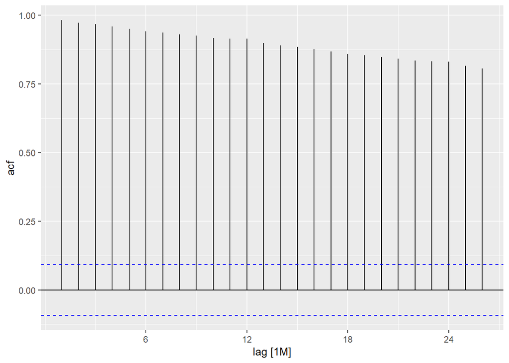

```r
myseries %>%
    ACF(Turnover) %>%
    autoplot()
```

#### Can you spot any seasonality, cyclicity and trend? What do you learn about the series?

The autoplot() graph shows a definite upward trend in retail turnover, with a hint of some sort of repeated pattern but it’s hard to tell from this generic plot. In looking at the gg_season() plot we again see more recent years (pink and purple) higher on the y-axis of retail turnover. Further, there is appears to be a dip in many years in February, with an increase in December. The gg_subseries() plot is a bit hard to read with the year-span so thin, but seeing the blue lines of what I assume is a median does show the dip in February and the slight increase in December I noticed earlier.

The gg_lag() plot shows a high correlation across all lags, while the ACF and plot might show a very slight scalloped shape which hints at the upward trend and minimal seasonality playing off of each other in this chart.

I’d feel fairly safe, at this stage of exploration, saying there appears to be an upward trend of retail turnover increasing as well as consistent peaks in December, dropping in January, and dropping to it’s lowest in February. March-November appear to be relatively steady.